# Zaawansowane Modele Liniowe - Sprawozdanie 5

Błażej Wiórek

5/23/2020

### Wprowadzenie do problemu

Pomiary wielokrotne to metodyka organizowania eksperymentów badawczych w taki sposób, że dane podmiotów badania są cyklicznie powtarzane w określonych punktach czasowych. Standardowym przykładem i jednocześnie podstawowym zakresem zastosowania takiego podejścia są dane kliniczne. W badaniach tych można badać np. skuteczność pewnego leku/leków na określonej grupie pacjentów. W podstawowym scenariuszu pacjenci dzieleni są na grupy ze względu na przyjmowany lek. Jako, że skutki kuracji rozłożone są w czasie, pacjenci podlegają okresowym kontrolom, podczas których zbierane są informacje na temat stanu ich zdrowia i skutków leczenia. Warto zwrócić uwagę, że przy takim scenariuszu nie można założyć niezależności obserwacji odpowiadających konkretnemu pacjentowi, można natomiast oczekiwać niezależności pomiędzy pacjentami.

Model, który można zastosować przy przedstawionej strukturze danych może mieć postać:
$$y_{ij}=X^T_{ij}\beta + \epsilon_{ij}$$
Przy czym uznajemy, że:

- $y_{ij}$ to j-ta obserwacja dla i-tego obiektu
- $X_{ij}$ wektor zmiennych objaśnianych dla i-tego obiektu w j-tej obserwacji
- $\epsilon_{ij} \sim N(0, \sigma_{ij}^2)$, przy czym $cov(\epsilon_{ij}, \epsilon_{lk})=0$ dla $i \neq l$, ale $cov(\epsilon_{ij}, \epsilon_{ik}) \neq 0$

Aby uwzględnić założenie o potencjalnej korelacji pomiędzy kolejnymi pomiarami danego podmiotu modeluje się rozkład łączny wektora zmiennych objaśnianych dla kolejnych pomiarów. Mam zatem: $y_i, N(X_i\beta, \Sigma)$, przy czym $cov((Y_{i1}, ..., Y_{ip})) = \Sigma$. Wniosek jest taki, że poza wyestymowaniem wektora współczynników modelu $\beta$, konieczne jest wyestymowanie macierzy kowariancji $\Sigma$. Aby zmniejszyć liczbę estymowanych parametrów stosuje się różnego rodzaju podejścia ograniczające strukturę macierzy $\Sigma$. W niniejszym zadaniu dane generowane są z modelu dla którego:

$$\beta=(3,3,0)^T$$

$$\Sigma =
\begin{pmatrix}
1 & \rho & ... & \rho\\
\rho & 1 & ... & \rho\\
... & ... & ... & ...\\\
\rho & \rho & ... & 1
\end{pmatrix}$$

Taką postać macierzy kowariancji nazywa się Compound Symmetry. W przedstawionym przypadku dodatkowym założeniem jest równość wariancji dla poszczególnych pomiarów.

Istnieją dwie podstawowe metody estymacji $\Sigma$. Pierwszy z nich oparty jest na numerycznym wyznaczeniu $\hat{\Sigma}$, korzystając z funkcji maximum likelihood. Okazuje się jednak, ze taka postać estymatora me tendencje do niedoszacowania wariancji (estymator jest obciążony). Sytuacje taką obserwuje się szczególnie w przypadku, gdy liczba obserwacji jest niewielka. Częściowym rozwiązaniem tego problemu jest skorzystanie z tzw. Restricted Maximum Likelihood Estimation (REML). Okazuje się, że często $\hat{\Sigma}_{REML}$ lepiej odzwierciedla strukturę kowariancji. Nie jest to jednak fakt poparty dowodem, ale zaledwie obserwacja empiryczna.

Aby przeprowadzić wnioskowanie na podstawie dopasowanego modelu konieczna jest znajomość rozkładu wektora parametrów $\beta$. Okazuje się, że można udowodnić następujący fakt:
$$\hat{\beta} \rightarrow N(\beta, (\sum^n_{i=1}X_i^T\Sigma^{-1}X_i)^{-1})$$

## Zadanie 1

```
## Generalized least squares fit by REML
##   Model: y ~ . - id - Time
##   Data: X_design
##        AIC      BIC    logLik
##   215.2797 227.4318 -101.6399
##
## Correlation Structure: Compound symmetry
##  Formula: ~1 | id
##  Parameter estimate(s):
##       Rho
## 0.4971741
##
## Coefficients:
##                 Value Std.Error   t-value p-value
## (Intercept)  1.027854 0.2939525  3.496668  0.0009
## X1           1.324128 1.2688161  1.043593  0.3012
## X2           1.775041 1.1530690  1.539406  0.1293
## X3          -1.842099 1.2552327 -1.467536  0.1478
##
##  Correlation:
##    (Intr) X1     X2
## X1 -0.089
## X2  0.002 -0.127
## X3  0.056 -0.204  0.031
##
## Standardized residuals:
##        Min         Q1        Med         Q3        Max
## -2.6795387 -0.5597662  0.1262550  0.6304396  1.8370575
##
## Residual standard error: 1.604689
## Degrees of freedom: 60 total; 56 residual
```

Na podstawie podsumowania dopasowanego modelu można zauważyć, że:

- Wariancja jest stała dla każdego pomiaru
- $\hat{\rho}=0.4971741$
- $p = 4$ = intercept + $X_1$ + $X_2$ + $X_3$

#### Podpunkt c) - wektor $\hat{\beta}$

Zadanie polega na porówaniu estymatora $\hat{\beta}$ oraz jego wariancji $cov(\hat{\beta})$ wyliczonych na podstawie wzorów:
$$\hat{\beta} = (\sum^n_{i=1}X_i^T \hat{\Sigma}^{-1} X_i)^{-1}(\sum^n_{i=1}X_i^T \hat{\Sigma}^{-1} y_i)$$

$$cov(\hat{\beta}) = (\sum^n_{i=1}X_i^T \hat{\Sigma}^{-1} X_i)^{-1}$$
oraz odpowiadających im wartości uzyskanych z dopasowanego modelu.

```
##           ML_coef REML_coef
## Intercept   1.028     1.028
## X 1         1.324     1.324
## X 2         1.775     1.775
## X 3        -1.842    -1.842
```

```
##                  (Intercept)     X1     X2     X3
## REML_(Intercept)       0.086 -0.033  0.001  0.021
## REML_X1               -0.033  1.610 -0.185 -0.325
## REML_X2                0.001 -0.185  1.330  0.046
## REML_X3                0.021 -0.325  0.046  1.576
## ML_(Intercept)         0.086 -0.033  0.001  0.021
## ML_X1                 -0.033  1.609 -0.185 -0.325
## ML_X2                  0.001 -0.185  1.329  0.046
## ML_X3                  0.021 -0.325  0.046  1.575
```

Jak sugerują nazwy kolumn, różnica pomiędzy wynikami wynika z różnicy w sposobie estymacji macierzy $\Sigma$, która to macierz wykorzystywana jest do wyznaczenia $\hat{\beta}$. Zaproponowane obliczenia ręczne związane są z $\hat{\Sigma}_{ML}$, natomiast wartości uzyskane z modelu odpowiadają $\hat{\Sigma}_{REML}$. Różnice pomiędzy wartościami są niewielkie. W tabeli poniżej przedstawiono wartość normy supremum dla odpowiednich estymatorów.

```
##   covariance_norm beta_norm
## 1           0.001         0
```

#### Podpunkt c) - macierz $\Sigma$

Aby ocenić jakość estymatora $\hat{\Sigma}_{REML}$ wystarczy porównać parametry $\rho$ oraz $\gamma$ z ich estymatorami. Wynika to z zastosowania macierzy kowariancji o strukturze Compound Symmetry i założenia o jednakowej wariancji w każdym z pomiarów.

```
##                   ro     gamma
## estimator  0.4971741 1.6046890
## true value 0.3000000 2.0000000
## norm       0.1971741 0.1904754
```

## Zadanie 2

Zadania 2, 3, 4, 5 i 6 mają na celu określenie wpływu aspektów takich jak: liczba obiektów, liczba pomiarów, liczba predyktorów i metoda estymacji macierzy $\Sigma$ na dopasowanie modelu. Wyniki eksperymentu prezentowane są w następujący sposób:

- Asymptotyczne własności estymatora $\beta$: Narysowane zostały histogramy dla $\beta_0$ oraz $\beta_1$ wraz z ich asymptotycznymi gęstościami. Dodatkowo zostało wyestymowane obciążenie estymatora $\beta$ ($\mathbb{E}[\hat{\beta} - \beta]$) oraz jego norma supremum.
- Asymptotyczne własności estymatora $\Sigma$: Narysowane zostały histogramy estymatorów $\hat{\rho}$ oraz $\hat{\gamma}$. Wyestymowane zostały obciążenia tych estymatorów.

Jako, że wszystkie podpunkty mają podobny charakter rozpocząłem od narysowania histogramów umieszczając w podpisach odpowiednie wartości, następnie przedstawione zostało całościowe zestawienie.

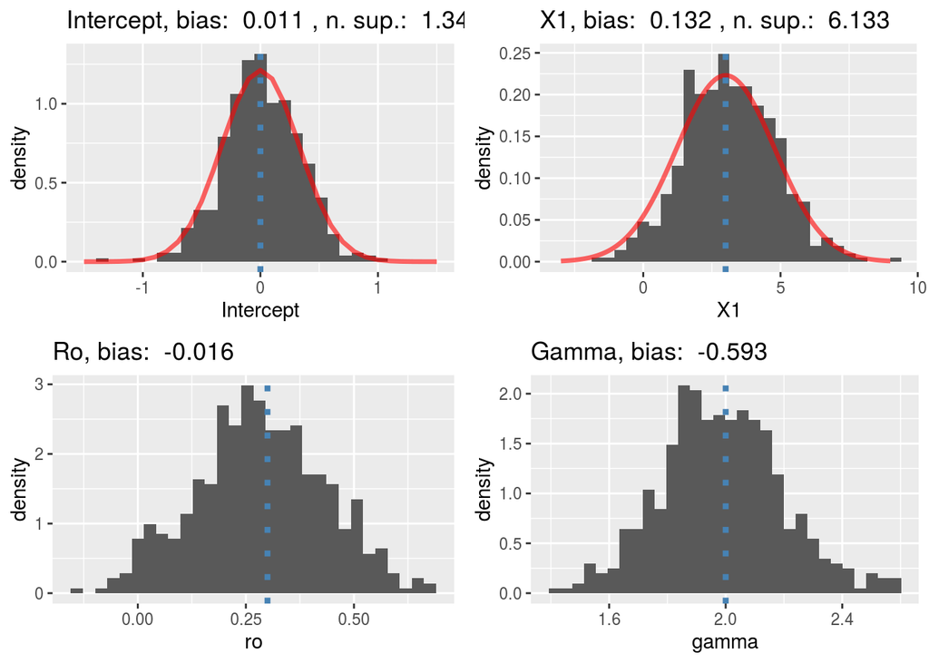

## Zadanie 3

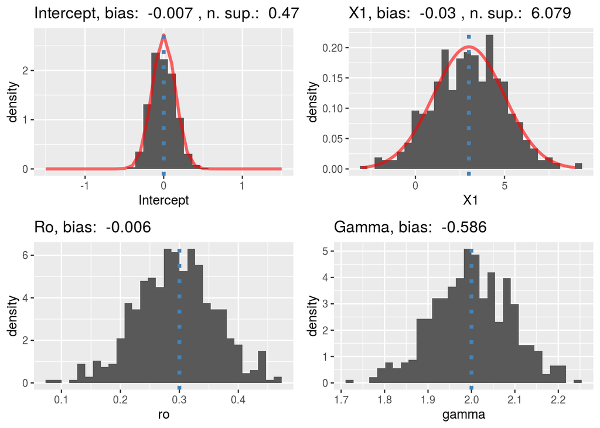

## Zadanie 4

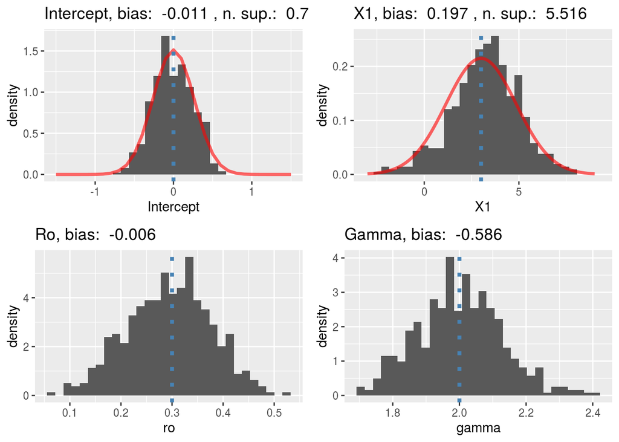

## Zadanie 5

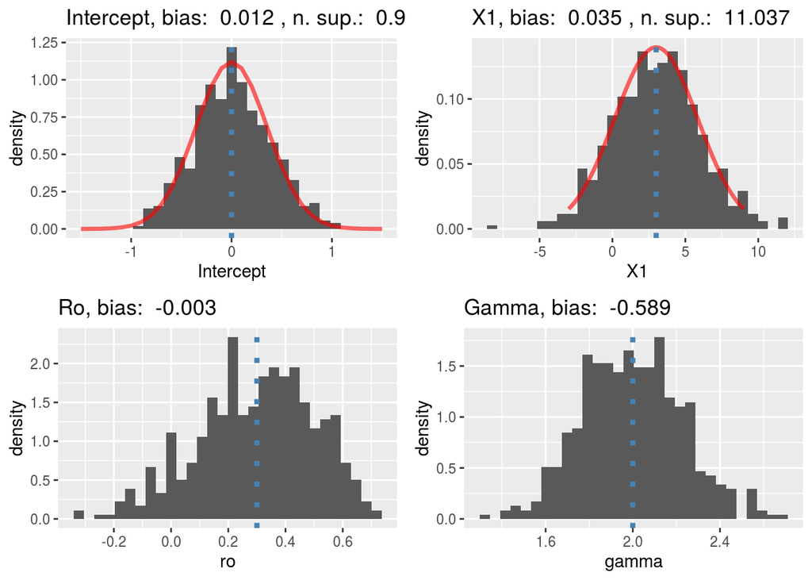

## Zadanie 6

## Zadanie 2 - ML

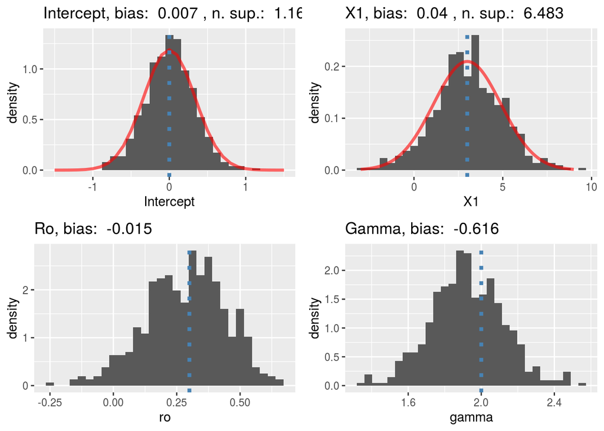

## Zadanie 3 - ML

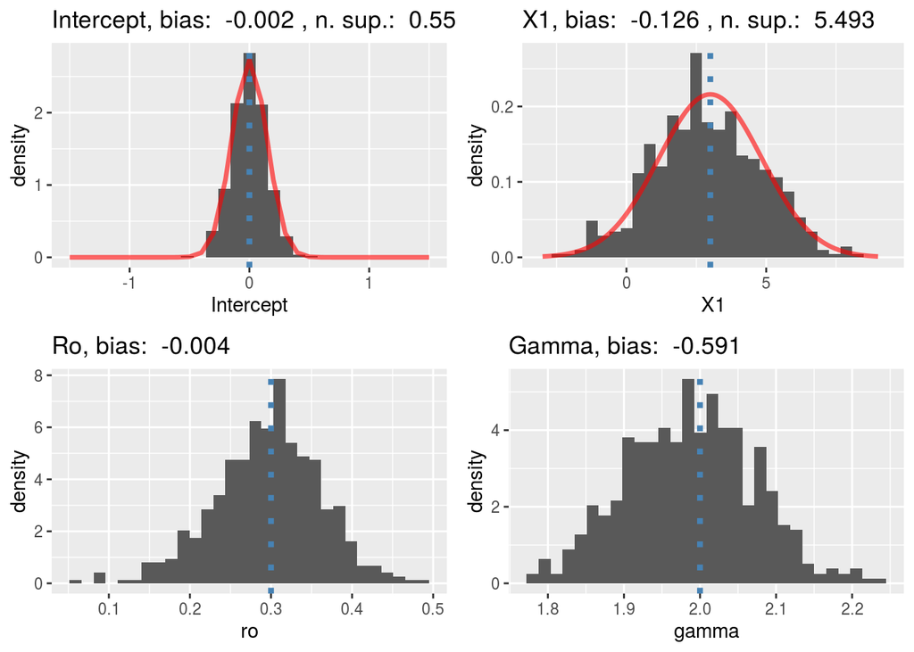

## Zadanie 4 - ML

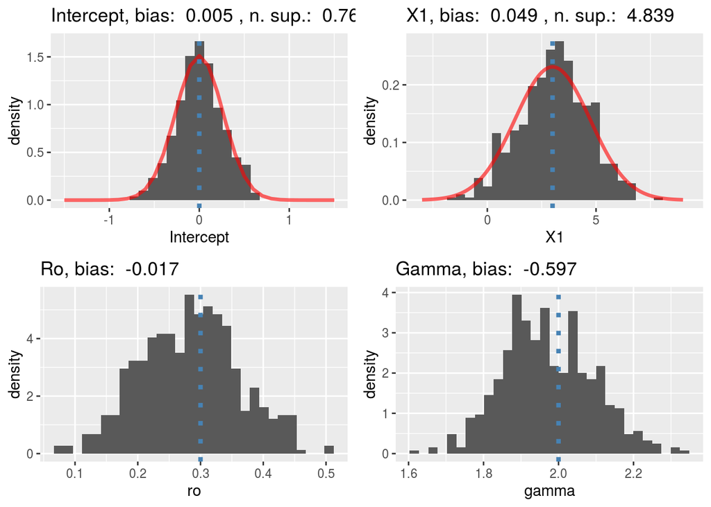

## Zadanie 5 - ML

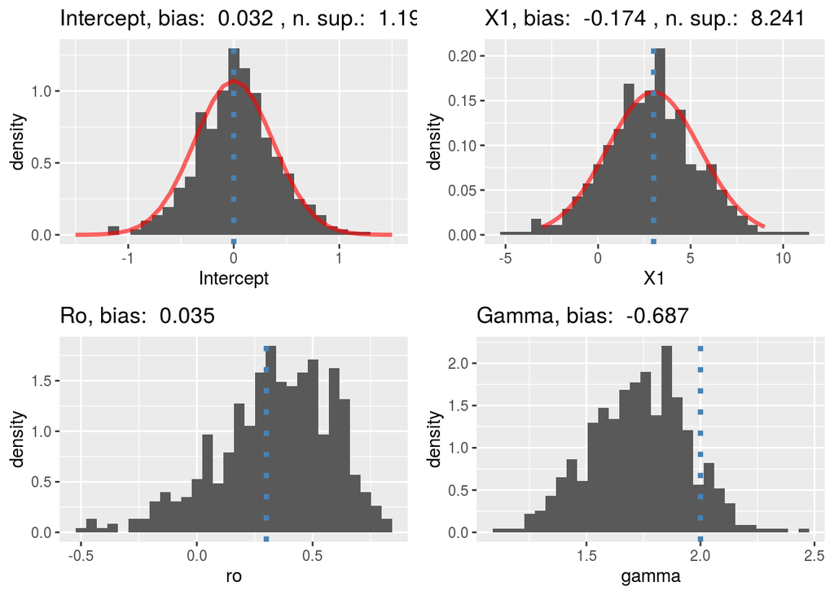

### Podsumowanie

```
##           int_bias int_norm x1_bias x1_norm ro_bias gamma_bias
## REML base   0.0105   1.3485  0.1319  6.1334 -0.0160    -0.5928
## REML ob    -0.0066   0.4741 -0.0298  6.0786 -0.0065    -0.5861
## REML trt   -0.0110   0.7257  0.1973  5.5160 -0.0060    -0.5862
## REML pred   0.0116   0.9904  0.0349 11.0374 -0.0033    -0.5891
## ML base     0.0073   1.1639  0.0396  6.4830 -0.0154    -0.6158
## ML ob      -0.0018   0.5519 -0.1260  5.4933 -0.0045    -0.5908
## ML trt      0.0052   0.7638  0.0489  4.8389 -0.0170    -0.5967
## ML pred     0.0317   1.1962 -0.1745  8.2410  0.0354    -0.6872
```

Przyjmuje następujące oznaczenia:

- n - liczba obiektów
- k - liczba pomiarów na każdym obiekcie
- p - liczba kolumn w macierzy planu
- N = n*k - liczba zmiennych objaśnianych $y_{ij}$

Wiersze oznaczone jako ‘base’ związane są ze scenariuszem wyjściowym, gdzie n=20, k=3, p=4.

- Scenariusz oznaczony ‘ob’ ma na celu sprawdzenie wpływu liczby obiektów tzn. n=100.
- Scenariusz oznaczony ‘trt’ ma na celu sprawdzenie wpływu liczby pomiarów tzn. k=15.
- Scenariusz oznaczony ‘pred’ ma na celu sprawdzenie wpływu liczby predyktorów tzn. p=20.

Obserwacje:

- Zwiększenie liczby obiektów spowodowało poprawę jakości estymacji
- Zwiększenie liczby pomiarów spowodowało poprawę jakości estymacji, jednak wydaje się, że poprawa jest mniejsza niż w przypadku zwiększenia liczby obiektów
- Zwiększenie liczby predyktorów spowodowało pogorszenie jakości estymowanych parametrów, szczególnie w przypadku ML

We wszystkich przypadkach rozkład przedstawiony na histogramach jest zbliżony do rozkładu asymptotycznego. Warto zauważyć, że w przypadku $\hat{\Sigma}_{ML}$ wartości biasu dla parametru gamma są niedoszacowane względem wartości prawdziwych oraz tych, które zostały otrzymane za pomocą REML.